# linear_regression

```python
import pandas as pd
import numpy as np
import matplotlib.pyplot as plt
import seaborn as sns
```

**Problem Statement Given a csv file with the information of users of a website and a mobile app for a certain company.**

Loading the csv file and reading the header

```python
customers = pd.read_csv('Ecommerce Customers')
```

```python
customers.head(20)
```

|  | Email | Address | Avatar | Avg. Session Length | Time on App | Time on Website | Length of Membership | Yearly Amount Spent |
| --- | --- | --- | --- | --- | --- | --- | --- | --- |
| 0 | mstephenson@fernandez.com | 835 Frank Tunnel\nWrightmouth, MI 82180-9605 | Violet | 34.497268 | 12.655651 | 39.577668 | 4.082621 | 587.951054 |
| 1 | hduke@hotmail.com | 4547 Archer Common\nDiazchester, CA 06566-8576 | DarkGreen | 31.926272 | 11.109461 | 37.268959 | 2.664034 | 392.204933 |
| 2 | pallen@yahoo.com | 24645 Valerie Unions Suite 582\nCobbborough, D... | Bisque | 33.000915 | 11.330278 | 37.110597 | 4.104543 | 487.547505 |
| 3 | riverarebecca@gmail.com | 1414 David Throughway\nPort Jason, OH 22070-1220 | SaddleBrown | 34.305557 | 13.717514 | 36.721283 | 3.120179 | 581.852344 |
| 4 | mstephens@davidson-herman.com | 14023 Rodriguez Passage\nPort Jacobville, PR 3... | MediumAquaMarine | 33.330673 | 12.795189 | 37.536653 | 4.446308 | 599.406092 |
| 5 | alvareznancy@lucas.biz | 645 Martha Park Apt. 611\nJeffreychester, MN 6... | FloralWhite | 33.871038 | 12.026925 | 34.476878 | 5.493507 | 637.102448 |
| 6 | katherine20@yahoo.com | 68388 Reyes Lights Suite 692\nJosephbury, WV 9... | DarkSlateBlue | 32.021596 | 11.366348 | 36.683776 | 4.685017 | 521.572175 |
| 7 | awatkins@yahoo.com | Unit 6538 Box 8980\nDPO AP 09026-4941 | Aqua | 32.739143 | 12.351959 | 37.373359 | 4.434273 | 549.904146 |
| 8 | vchurch@walter-martinez.com | 860 Lee Key\nWest Debra, SD 97450-0495 | Salmon | 33.987773 | 13.386235 | 37.534497 | 3.273434 | 570.200409 |
| 9 | bonnie69@lin.biz | PSC 2734, Box 5255\nAPO AA 98456-7482 | Brown | 31.936549 | 11.814128 | 37.145168 | 3.202806 | 427.199385 |
| 10 | andrew06@peterson.com | 26104 Alexander Groves\nAlexandriaport, WY 282... | Tomato | 33.992573 | 13.338975 | 37.225806 | 2.482608 | 492.606013 |
| 11 | ryanwerner@freeman.biz | Unit 2413 Box 0347\nDPO AA 07580-2652 | Tomato | 33.879361 | 11.584783 | 37.087926 | 3.713209 | 522.337405 |
| 12 | knelson@gmail.com | 6705 Miller Orchard Suite 186\nLake Shanestad,... | RoyalBlue | 29.532429 | 10.961298 | 37.420216 | 4.046423 | 408.640351 |
| 13 | wrightpeter@yahoo.com | 05302 Dunlap Ferry\nNew Stephaniehaven, MP 42268 | Bisque | 33.190334 | 12.959226 | 36.144667 | 3.918542 | 573.415867 |
| 14 | taylormason@gmail.com | 7773 Powell Springs Suite 190\nSamanthaland, N... | DarkBlue | 32.387976 | 13.148726 | 36.619957 | 2.494544 | 470.452733 |
| 15 | jstark@anderson.com | 49558 Ramirez Road Suite 399\nPhillipstad, OH ... | Peru | 30.737720 | 12.636606 | 36.213763 | 3.357847 | 461.780742 |
| 16 | wjennings@gmail.com | 6362 Wilson Mountain\nJohnsonfurt, GA 15169 | PowderBlue | 32.125387 | 11.733862 | 34.894093 | 3.136133 | 457.847696 |
| 17 | rebecca45@hale-bauer.biz | 8982 Burton Row\nWilsonton, PW 88606 | OliveDrab | 32.338899 | 12.013195 | 38.385137 | 2.420806 | 407.704548 |
| 18 | alejandro75@hotmail.com | 64475 Andre Club Apt. 795\nPort Dannytown, PW ... | Cyan | 32.187812 | 14.715388 | 38.244115 | 1.516576 | 452.315675 |
| 19 | samuel46@love-west.net | 544 Alexander Heights Suite 768\nNorth Johnvie... | LightSeaGreen | 32.617856 | 13.989593 | 37.190504 | 4.064549 | 605.061039 |

```python
customers.info()
```

```
<class 'pandas.core.frame.DataFrame'>
RangeIndex: 500 entries, 0 to 499
Data columns (total 8 columns):
Email                   500 non-null object
Address                 500 non-null object
Avatar                  500 non-null object
Avg. Session Length     500 non-null float64
Time on App             500 non-null float64
Time on Website         500 non-null float64
Length of Membership    500 non-null float64
Yearly Amount Spent     500 non-null float64
dtypes: float64(5), object(3)
memory usage: 31.3+ KB
```

```python
customers.describe()
```

|  | Avg. Session Length | Time on App | Time on Website | Length of Membership | Yearly Amount Spent |
| --- | --- | --- | --- | --- | --- |
| count | 500.000000 | 500.000000 | 500.000000 | 500.000000 | 500.000000 |
| mean | 33.053194 | 12.052488 | 37.060445 | 3.533462 | 499.314038 |
| std | 0.992563 | 0.994216 | 1.010489 | 0.999278 | 79.314782 |
| min | 29.532429 | 8.508152 | 33.913847 | 0.269901 | 256.670582 |
| 25% | 32.341822 | 11.388153 | 36.349257 | 2.930450 | 445.038277 |
| 50% | 33.082008 | 11.983231 | 37.069367 | 3.533975 | 498.887875 |
| 75% | 33.711985 | 12.753850 | 37.716432 | 4.126502 | 549.313828 |
| max | 36.139662 | 15.126994 | 40.005182 | 6.922689 | 765.518462 |

*starting to get a sense of the data, graphing using seaborn a few plots cmparing columns and trying to find any correlation or trend. Basic Stuff still*

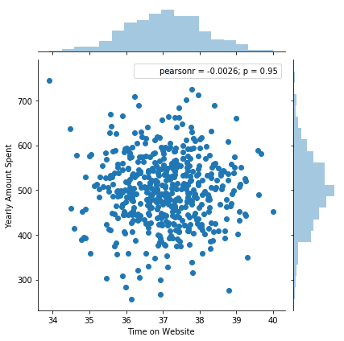

```python
sns.jointplot(data = customers, x='Time on Website', y='Yearly Amount Spent')
```

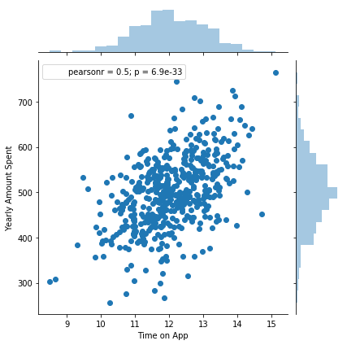

```python
sns.jointplot(data = customers, x='Time on App', y='Yearly Amount Spent')
```

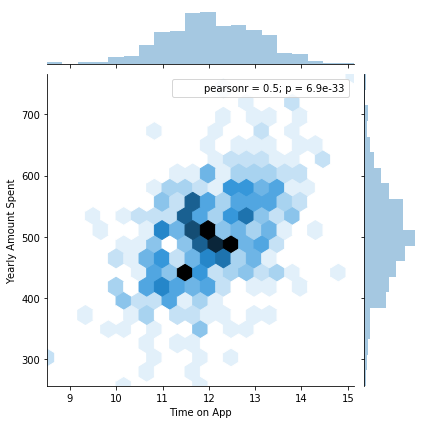

```python
sns.jointplot(x='Time on App', y='Yearly Amount Spent', kind='hex', data=customers)
```

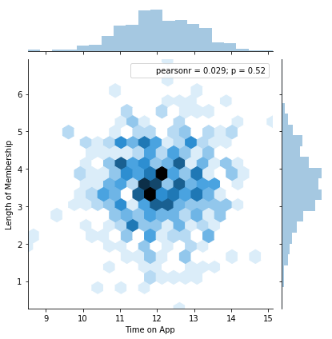

```python
sns.jointplot(x='Time on App', y='Length of Membership', kind='hex', data=customers)
```

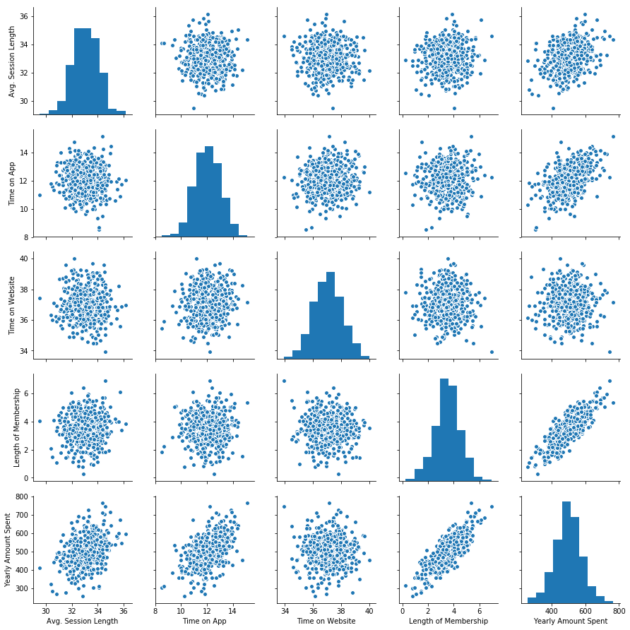

```python
sns.pairplot(data=customers)
```

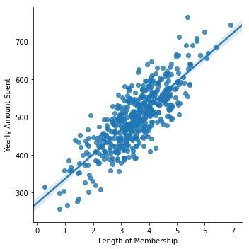

```python
sns.lmplot(x='Length of Membership', y='Yearly Amount Spent', data=customers)
```

*it seems that yearly amount spent has a high dependancy ont he length of membership*

```python
customers.columns
```

```
Index(['Email', 'Address', 'Avatar', 'Avg. Session Length', 'Time on App',
       'Time on Website', 'Length of Membership', 'Yearly Amount Spent'],
      dtype='object')
```

**Split the data into training and testing data using sklearn.model_selection train_test_split**

```python
y = customers['Yearly Amount Spent']
```

```python
X = customers[['Avg. Session Length', 'Time on App',
       'Time on Website', 'Length of Membership']]
```

```python
from sklearn.model_selection import train_test_split
```

```python
X_train, X_test, y_train, y_test = train_test_split(X, y,test_size=0.3, random_state=101)
```

```python
from sklearn.linear_model import LinearRegression
```

Create an instance of the linear regression model.

```python
lm = LinearRegression()
```

```python
X_train.head()
```

|  | Avg. Session Length | Time on App | Time on Website | Length of Membership |
| --- | --- | --- | --- | --- |
| 202 | 31.525752 | 11.340036 | 37.039514 | 3.811248 |
| 428 | 31.862741 | 14.039867 | 37.022269 | 3.738225 |
| 392 | 33.258238 | 11.514949 | 37.128039 | 4.662845 |
| 86 | 33.877779 | 12.517666 | 37.151921 | 2.669942 |
| 443 | 33.025020 | 12.504220 | 37.645839 | 4.051382 |

```python
lm.fit(X_train,y_train)
```

```
LinearRegression(copy_X=True, fit_intercept=True, n_jobs=1, normalize=False)
```

```python
coefficients = lm.coef_
```

```python
predictions = lm.predict(X_test)
```

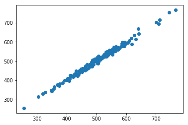

```python
plt.scatter(y_test, predictions)
# for some reason the code below is giving an error (Check this later and correct)
# plt.xlabel("Test values")
# plt.ylabel("Predicted Values")
```

*Graphing the real y_test data and vs the Prediction data (above) we see that the line is linear and our model is successful.*

Below, we do further analysis on the results of our model.

```python
from sklearn import metrics
```

```python
print('MAE', metrics.mean_absolute_error(y_test, predictions))
```

```
MAE 7.228148653430838
```

```python
print('MSE', metrics.mean_squared_error(y_test, predictions))
```

```
MSE 79.81305165097461
```

```python
print('MSQRTE', np.sqrt(metrics.mean_squared_error(y_test, predictions)))
```

[output not shown]

```python
metrics.explained_variance_score(y_test, predictions)
```

```
0.9890771231889606
```

Plotting a distibution curve of our the residuals. Basically our difference between the y_test and the prediction data. This curve will show if our errrors are normally distributed.

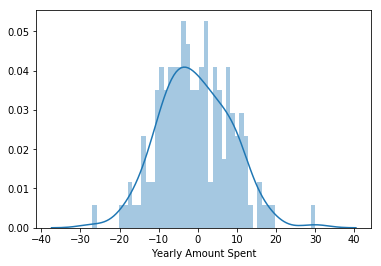

```python
sns.distplot(y_test-predictions, bins=50)
```

```python
coefficients_df = pd.DataFrame(coefficients, X.columns)
```

```python
print(coefficients_df)
```

```
                              0
Avg. Session Length   25.981550
Time on App           38.590159
Time on Website        0.190405
Length of Membership  61.279097
```

**The table above shows the coefficients of our model. Basically, it means that if all other variables are held constant, a one unit increase in the Avg session legth will result in an increase of spending of $25.98 .. The length of membership is highly correlated, and we should investigate further why spending time on the website does not result in that much more spending.**